# 54-xgboost-performance

In this notebook we explore the performance of the Xgboost model. Additionally, we will confirm the behavior of cross validation and hyperparameter tuning.

**Make sure you run the 43-xgboost-modeling notebook before attempting to run this notebook if you want to generate new results.**

# 1 Load Saved Data

```r
#move_model_info('xgb', 'load');
```

# 2 Selected Model Performance Evaluation

## 2.1 Cross validation metrics from best model

Let’s first evaluate the performance using the cross-validation metrics from before. However, here, we’ll only look at the best model.

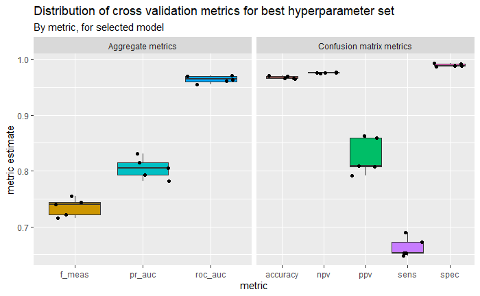

```r
#get best xgboost metrics
best_xgb_fold_metrics <- calculate_best_performance_metrics(xgb_fold_metrics, best_xgb_params)
```

```r
best_xgb_fold_metrics %>%
  group_by(.metric) %>%
  summarize(overall_perf = mean(.estimate))
```

|  | .metric | overall_perf |
| --- | --- | --- |
| 1 | accuracy | 0.9674498 |
| 2 | f_meas | 0.7352150 |
| 3 | npv | 0.9757426 |
| 4 | ppv | 0.8258297 |
| 5 | pr_auc | 0.8050726 |
| 6 | roc_auc | 0.9640631 |
| 7 | sens | 0.6630851 |
| 8 | spec | 0.9896713 |

## 2.2 Performance on training data as a whole

Here, we look at the confusion matrix for the entire training set as well as computations from the confusion matrix.

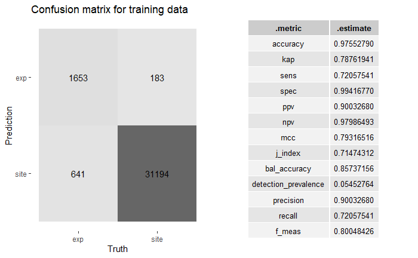

```r
#get prediction class and probabilities
xgb_training_preds <- get_prediction_dataframes(xgb_final_fit, train_data)
#plot and calculate confusion matrix
t1 <- calculate_confusion_matrix(xgb_training_preds)
```

# 3 Explaining the model

## 3.1 Variable importance

What parameters are contributing most strongly to the classification? Do we see evidence of data snooping? Let’s take a look!

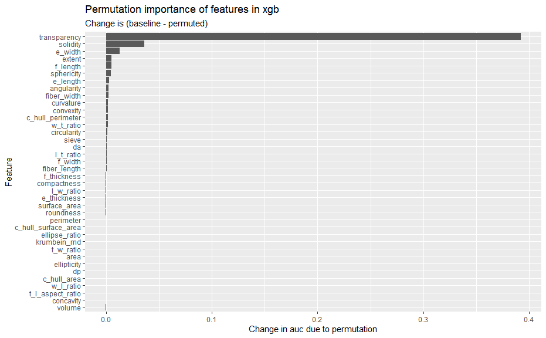

```r
xgb_vip <- plot_variable_importance(xgb_final_fit, assessment_data=train_data, mdl_name = 'xgb', positive_class='exp')
```

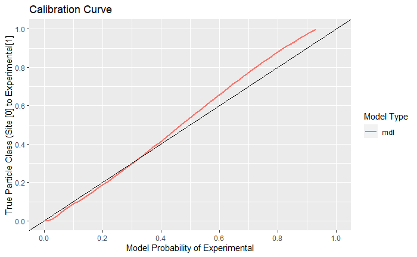

```r
plot_calibration_curve(xgb_training_preds)
```

```
    === AUCs ===

     Model name Dataset ID Curve type       AUC
   1    xgboost          1        ROC 0.9818538
   2    xgboost          1        PRC 0.8806088

    === Input data ===

     Model name Dataset ID # of negatives # of positives
   1    xgboost          1          31377           2294
```

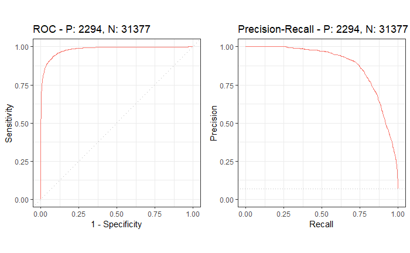

```r
plot_performance_curves(xgb_training_preds, model_names='xgboost',pos_class='exp')
```

These curves reflect relatively good training performance. This shows that this model type is able to learn on this data.

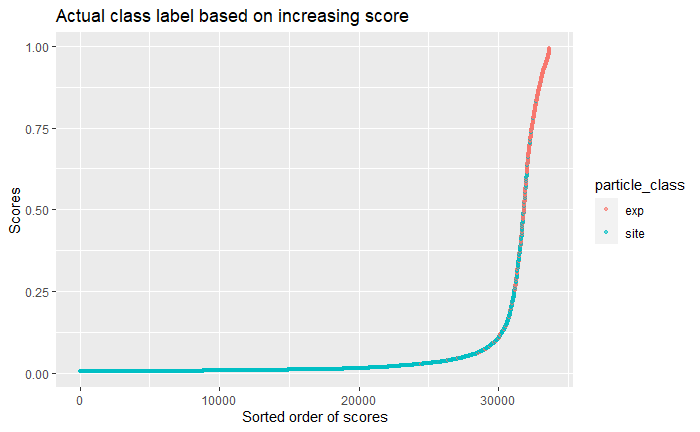

```r
plot_label_by_score(xgb_training_preds)
```

These results suggest that the threshold of 0.5 seems to be about right for general purpose investigation and further changes to this threshold will need to be based on the use-case.

# 4 Save markdown file

```r
fs::file_copy('54-xgboost-performance.nb.html', './html_results/54-xgboost-performance.nb.html', overwrite=TRUE)
```